# Tarea 3

Exercise done by Cédric Prieels, for the Machine Learning II course.

## Scalable kernel methods

The main objective of this exercise consists in creating a script able to download hml data in order to predict houses price using kernel ridge regression.

For this, several steps will be followed: first of all, the data will be downloaded and shortly analyzed. Then, once divided into a test and a train dataset, a linear regression will be performed in order to predict the price of the house based on 16 different input characteristics. Final, a kernel ridge regression method will be trained, using the Nyström or RFF approximation and the mean absolute error obtained by both methods will be compared.

### Data download and analysis

The data is available on the web, using the URL https://www.openml.org/d/574. Let's use sklearn's fetch_openml function to read this data.

```python
from sklearn.datasets import fetch_openml

#To download the data from OpenML we just need its id, 574 in this case
data = fetch_openml(data_id=574)
data.details #Let's print the details of the dataset considered
```

```
{'id': '574',
 'name': 'house_16H',
 'version': '1',
 'format': 'ARFF',
 'upload_date': '2014-10-03T21:53:19',
 'licence': 'Public',
 'url': 'https://www.openml.org/data/v1/download/52752/house_16H.arff',
 'file_id': '52752',
 'default_target_attribute': 'price',
 'tag': 'study_130',
 'visibility': 'public',
 'status': 'active',
 'processing_date': '2018-10-03 21:22:39',
 'md5_checksum': 'f91f984acadd75e0c1400aaadcb94c35'}
```

Let's now have a look at the data just downloaded. We can get started by looking at the type of the data variable.

```python
print("Data type\n " + str(type(data)))
```

```
Data type
 <class 'sklearn.utils.Bunch'>
```

The data variable seems to be an object having the type <class 'sklearn.utils.Bunch'>. This is a sklearn format representing a dictionary-like object that exposes its keys and attributes.

This means that we can now easily access this object's description to understand a bit more about the dataset considered.

```python
print(data.DESCR) #Print a description of the object
```

```
**Author**:
**Source**: Unknown - Date unknown
**Please cite**:

This database was designed on the basis of data provided by US Census
Bureau [http://www.census.gov] (under Lookup Access
[http://www.census.gov/cdrom/lookup]: Summary Tape File 1). The data
were collected as part of the 1990 US census. These are mostly counts
cumulated at different survey levels. For the purpose of this data set
a level State-Place was used. Data from all states was obtained. Most
of the counts were changed into appropriate proportions.  There are 4
different data sets obtained from this database: House(8H) House(8L)
House(16H) House(16L) These are all concerned with predicting the
median price of the house in the region based on demographic
composition and a state of housing market in the region. A number in
the name signifies the number of attributes of the data set. A
following letter denotes a very rough approximation to the difficulty
of the task. For Low task difficulty, more correlated attributes were
chosen as signified by univariate smooth fit of that input on the
target. Tasks with High difficulty have had their attributes chosen to
make the modelling more difficult due to higher variance or lower
correlation of the inputs to the target.

Original source: DELVE repository of data.
Source: collection of regression datasets by Luis Torgo (ltorgo@ncc.up.pt) at
http://www.ncc.up.pt/~ltorgo/Regression/DataSets.html
Characteristics: 22784 cases, 17 continuous attributes.

Downloaded from openml.org.
```

We can see that the data collected concerns the price of the houses in all the states in the US in 1990. A total of 16 different attributes are also present in this data, as we can now check, even though do not seem to be very instructive. In order to understand better the data, let's also keep it in a panda data frame to study it in an easier way later on.

```python
import numpy as np
import pandas as pd

print("Features of the dataset: " + str(data.feature_names))

#Let's create a panda dataframe
#Each column will be a different feature, and we set the last column to be the target value
df = pd.DataFrame(data= np.c_[data['data'], data['target']], columns= data['feature_names'] + ['target'])
print()
print(df.head(5))
```

```
Features of the dataset: ['P1', 'P5p1', 'P6p2', 'P11p4', 'P14p9', 'P15p1', 'P15p3', 'P16p2', 'P18p2', 'P27p4', 'H2p2', 'H8p2', 'H10p1', 'H13p1', 'H18pA', 'H40p4']

        P1      P5p1      P6p2     P11p4     P14p9     P15p1     P15p3  \
0  15512.0  0.460869  0.049252  0.226470  0.149827  0.752837  0.010057
1   1550.0  0.470968  0.002581  0.137419  0.096341  0.862581  0.000000
2   4741.0  0.485341  0.000211  0.189412  0.135656  0.856992  0.000000
3    467.0  0.498929  0.000000  0.100642  0.085470  0.907923  0.000000
4    310.0  0.474193  0.680645  0.225806  0.128834  0.896774  0.000000

      P16p2     P18p2     P27p4      H2p2      H8p2     H10p1     H13p1  \
0  0.579729  0.003251  0.075912  0.625318  0.036613  0.991377  0.260116
1  0.695142  0.005025  0.043551  0.064263  0.003350  0.994975  0.285266
2  0.683584  0.004143  0.027965  0.065796  0.000000  0.997411  0.315433
3  0.780488  0.006098  0.018293  0.057471  0.000000  1.000000  0.149425
4  0.756302  0.008403  0.016807  0.077519  0.672269  0.991597  0.147287

      H18pA     H40p4    target
0  0.052246  0.774059  130600.0
1  0.060606  0.142857   40500.0
2  0.065116  0.687500   28700.0
3  0.139535  1.000000   28500.0
4  0.000000  0.000000   24100.0
```

```python
print(df.describe()) #Print a description of eahc column
```

```
                 P1          P5p1          P6p2         P11p4         P14p9  \
count  2.278400e+04  22784.000000  22784.000000  22784.000000  22784.000000
mean   7.808669e+03      0.482297      0.063982      0.163900      0.121538
std    6.587242e+04      0.031876      0.150921      0.080461      0.056687
min    2.000000e+00      0.125000      0.000000      0.000000      0.000000
25%    4.270000e+02      0.464647      0.000000      0.112069      0.081236
50%    1.345500e+03      0.480396      0.003413      0.155485      0.117127
75%    4.518250e+03      0.496040      0.033376      0.203596      0.156757
max    7.322564e+06      0.923077      1.000000      0.917255      0.511872

              P15p1         P15p3         P16p2         P18p2         P27p4  \
count  22784.000000  22784.000000  22784.000000  22784.000000  22784.000000
mean       0.851076      0.020487      0.716131      0.003589      0.033263
std        0.079455      0.057666      0.087264      0.005100      0.029567
min        0.054156      0.000000      0.233702      0.000000      0.000000
25%        0.819686      0.000000      0.662283      0.000000      0.016260
50%        0.863645      0.000000      0.714286      0.002591      0.027523
75%        0.899657      0.019196      0.771039      0.005007      0.042827
max        1.000000      0.943325      1.000000      0.125000      0.705736

               H2p2          H8p2         H10p1         H13p1         H18pA  \
count  22784.000000  22784.000000  22784.000000  22784.000000  22784.000000
mean       0.110527      0.057437      0.967045      0.304993      0.107377
std        0.105925      0.139811      0.099953      0.133998      0.090065
min        0.000000      0.000000      0.003257      0.000000      0.000000
25%        0.049303      0.000000      0.981410      0.221673      0.052770
50%        0.081179      0.002538      0.994100      0.299800      0.086957
75%        0.131430      0.029928      1.000000      0.375000      0.137931
max        0.975177      1.000000      1.000000      1.000000      1.000000

              H40p4         target
count  22784.000000   22784.000000
mean       0.491626   50074.439782
std        0.331655   52843.475551
min        0.000000       0.000000
25%        0.243243   21000.000000
50%        0.500000   33200.000000
75%        0.750000   56100.000000
max        1.000000  500001.000000
```

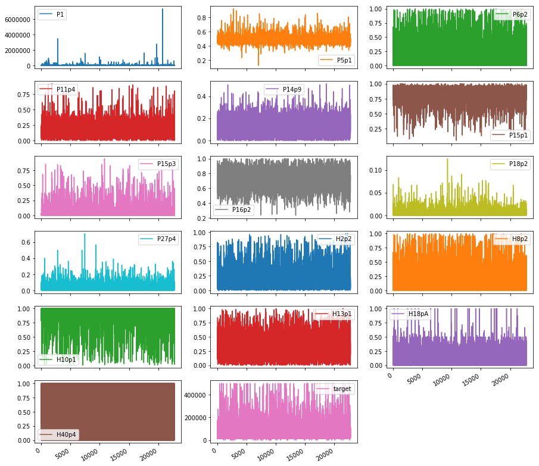

```python
import matplotlib.pyplot as plt
%matplotlib inline

#Now, plot the data
plt.figure()
df.plot(subplots=True, figsize=(15, 15), layout=(6,3))
#df[:500].plot(subplots=True, figsize=(15, 15), layout=(6,3)) #Plotting 500 rows is already a lot, the rest does not really add additional information
plt.show()
```

### Dataset division

The next step consists in dividing our dataset into train (2/3) and test (1/3). This is quite easy to do thanks to the sklearn package. Before doing so, the first step is to normalize the house price in order to avoid avoir huge numbers for the error and any potential issue with the regression (this is especially true if we use the MSE instead of the MAE, as done in this exercise).

```python
from sklearn.preprocessing import StandardScaler #To normalize the data
from sklearn.model_selection import train_test_split

normalizedData = StandardScaler().fit_transform(data.data)
normalizedTarget = StandardScaler().fit_transform(data.target.reshape(-1, 1))

#Let's use the random_state option for this exercise to always get the same splitting when dividing the data
X_train, X_test, y_train, y_test = train_test_split(normalizedData, normalizedTarget, test_size=0.33, random_state=0)
```

### Linear regression

We are now ready for the analysis itself. Let's start by performing a linear regression on this data, to study the target variable (house price) with respect to the 16 features previously described. We can also compute at this stage the Mean Absolute Error (MAE) on the test sample.

```python
from sklearn.linear_model import LinearRegression
from sklearn.metrics import mean_absolute_error
from sklearn.preprocessing import StandardScaler

lin_reg = LinearRegression()
lin_reg.fit(X_train, y_train)
y_pred_lin_reg = lin_reg.predict(X_test)

#Calculate the mean absolute error
mae_lin_reg = mean_absolute_error(y_test, y_pred_lin_reg)

#Print MAE values in standard and dB scale
print('MAE for Linear Regression: %.4f'%mae_lin_reg)
print('MAE (dB) for Linear Regression: %.4f'%(10*np.log10(mae_lin_reg)))
```

```
MAE for Linear Regression: 0.4822
MAE (dB) for Linear Regression: -3.1681
```

### Kernel Ridge Regression

```python
from sklearn.kernel_approximation import RBFSampler
from sklearn.kernel_approximation import Nystroem
from sklearn.model_selection import GridSearchCV

#Define the grid search parameters
parameters = {}
parameters['feature_map__gamma'] = [0.001, 0.005, 0.01, 0.05, 0.1, 0.5, 1.0]

#Nystroem approximation
feature_map_nystroem = Nystroem(gamma=0.1, n_components=200, random_state=0) #Let's only use 200 components for efficiency purposes
pipeline_nystroem = pipeline.Pipeline([("feature_map", feature_map_nystroem), ("ridge", LinearRegression())]) #Perform a linear regression after the approximation

clf_nystroem = GridSearchCV(pipeline_nystroem, cv=5, param_grid=parameters, scoring = 'neg_mean_absolute_error')

#RFF approximation
feature_map_fourier = RBFSampler(gamma=0.1, n_components=200, random_state=0)
pipeline_fourier = pipeline.Pipeline([("feature_map", feature_map_fourier), ("ridge", LinearRegression())])

clf_fourier = GridSearchCV(pipeline_fourier, cv=5, param_grid=parameters, scoring = 'neg_mean_absolute_error')
```

```python
#Train and predict - this takes a while
clf_nystroem.fit(X_train, y_train)
clf_fourier.fit(X_train, y_train)

y_pred_nystroem = clf_nystroem.predict(X_test)
y_pred_fourier = clf_fourier.predict(X_test)

print('Best parameters for Nystroem: '+ str(clf_nystroem.best_params_))
print('Best parameters for RFF: '+ str(clf_fourier.best_params_))
```

```
Best parameters for Nystroem: {'feature_map__gamma': 0.05}
Best parameters for RFF: {'feature_map__gamma': 0.01}
```

This gridsearch allowed us to determine that the best gamma parameter for the Nyström approximation is 0.05, while the best gamma for the RFF is 0.01. Let's now study both our predictions obtained using both approximations.

```python
#Calculate the mean absolute error for the best model in each case
mae_nystroem = mean_absolute_error(y_test, y_pred_nystroem)
mae_fourier = mean_absolute_error(y_test, y_pred_fourier)

#Print MAE values in standard and dB scale
print('MAE for Nystrom Approximation: %.4f'%mae_nystroem)
print('MAE (dB): %.4f'%(10*np.log10(mae_nystroem)))

print('MAE for RFF Approximation: %.4f'%mae_fourier)
print('MAE (dB): %.4f'%(10*np.log10(mae_fourier)))
```

```
MAE for Nystrom Approximation: 0.3996
MAE (dB): -3.9842
MAE for RFF Approximation: 0.4308
MAE (dB): -3.6573
```

We see that both approximations give results better than the one obtained for the linear regression, since the mean absolute error is quite lower. We can also conclude that, in this particular case, the Nystrom approximation seems to give an error a bit lower than the RFF approximation.

When repeating the same exercise using non-normalized datasets, we obtain an MAE of 28282 (gamma = 0.001) for the Nystrom approximation and 29339 (gamma = 0.001) for the RFF approximation (however, the gamma parameters set in this case for the grid search are probably not optimal).